# Water & Sediment Quality Analysis - Pilcomayo.net 2024

Author

Katerina Bischel - River Remedy

Published

July 15, 2025

## Water Quality Analysis Visual Guide

### Overview

This guide explains each visualization and analysis component in the Pilcomayo River water quality assessment, helping interpret the results and understand contamination patterns.

## 1. Station Overview Table

**What it shows:** Complete inventory of all monitoring stations with their codes, sampling dates, river locations, and GPS coordinates.

**Key insights to look for:**

- Geographic distribution of sampling points
- Which rivers/tributaries are being monitored
- Temporal coverage of the sampling campaign
- Data quality (complete vs. missing coordinates)

**Interpretation:** This table establishes the scope and coverage of the monitoring network. Stations with missing coordinates cannot be mapped spatially.

## 2. Interactive Spatial Distribution Map

**What it shows:** Geographic locations of all monitoring stations color-coded by river system.

**Color coding:**

- **Red markers:** Pilcomayo River main stem
- **Blue markers:** Tarapaya River system
- **Green markers:** Ribera River system
- **Orange markers:** Other water bodies

**How to interpret:**

- Cluster patterns indicate monitoring intensity in specific areas
- Upstream vs. downstream positioning relative to potential contamination sources
- Coverage gaps where additional monitoring might be needed
- Proximity to mining operations or urban areas

**Click on markers** to see detailed station information including coordinates, river name, and sampling date.

## 3. Heavy Metals Contamination Assessment Table

**What it shows:** Comprehensive analysis comparing measured heavy metal concentrations against WHO drinking water guidelines.

**Key columns explained:**

- **n_samples:** Number of measurements for each metal
- **mean_conc:** Average concentration across all stations
- **max_conc:** Highest concentration detected
- **who_limit:** WHO/EPA safety threshold
- **exceedance_ratio:** How many times above safe limits (>1 = concern)
- **contamination_level:** Risk categorization

**Color coding:**

- **Green (Safe):** Below WHO guidelines
- **Yellow (Moderate):** 1-2x above guidelines
- **Orange (High):** 2-5x above guidelines
- **Red (Critical):** >5x above guidelines

**What to prioritize:** Focus on metals with high exceedance ratios and critical/high contamination levels.

## 4. Heavy Metals Distribution Boxplot

**What it shows:** Statistical distribution of each heavy metal concentration across all monitoring stations (log scale).

**How to read boxplots:**

- **Box:** 25th to 75th percentile (middle 50% of data)
- **Line in box:** Median concentration
- **Whiskers:** Data range (excluding outliers)
- **Individual dots:** Each represents one monitoring station
- **Outliers:** Stations with unusually high concentrations

**Log scale explanation:** Because metal concentrations can vary by orders of magnitude, the y-axis uses log₁₀ scale. Each unit represents a 10-fold increase.

**Key insights:**

- Metals ranked by median contamination level
- Variability between stations (wide boxes = high variability)
- Outlier stations that need immediate attention
- Which metals show consistently elevated levels

## 5. Spatial Contamination Map

**What it shows:** Geographic distribution of contamination severity using a composite contamination index.

**Marker characteristics:**

**Contamination index calculation:**

- Average of all heavy metal ratios (concentration ÷ WHO limit) per station
- Accounts for multiple contaminants simultaneously
- Provides overall contamination “hotspot” identification

**Spatial patterns to look for:**

- Downstream contamination gradients
- Point source vs. diffuse contamination
- Proximity to mining operations
- Tributary vs. main stem differences

**Pop-up information includes:**

- Overall contamination category
- Average ratio vs. WHO guidelines
- Number of metals exceeding limits
- River system identification

## 6. Water Quality Parameters Summary & Plots

**What it shows:** Traditional water quality indicators that affect aquatic ecosystem health.

**Key parameters:**

- **pH:** Acidity/alkalinity (6.5-8.5 ideal for aquatic life)
- **Dissolved oxygen:** Essential for fish survival (>5 mg/L needed)
- **Conductivity:** Indicates dissolved salts/minerals
- **Turbidity:** Water clarity (higher = more suspended particles)

**Multi-panel boxplot interpretation:**

- Each panel shows one parameter across all stations
- Station-to-station variability within each parameter
- Stations consistently above/below normal ranges
- Parameters that correlate with contamination

**Water quality standards:**

- Values outside safe ranges stress aquatic ecosystems
- Multiple parameter exceedances indicate severe degradation
- Useful for understanding ecosystem impacts beyond toxicity

## 7. Correlation Analysis Matrix

**What it shows:** Statistical relationships between different contaminants and water quality parameters.

**Why correlations matter:**

- **Strong positive correlations** suggest common sources
- **Metal-metal correlations** indicate shared contamination pathways
- **Metal-water quality correlations** show ecosystem impacts
- **Clusters of correlations** help identify contamination signatures

**Practical applications:**

- Predict unmeasured contaminants from measured ones
- Identify contamination source types
- Design more efficient monitoring programs
- Understand contamination mechanisms

## 8. Priority Contamination Areas Table

**What it shows:** Ranked list of monitoring stations requiring immediate remediation attention.

**Ranking criteria:**

- **High/Critical contamination category**
- **Multiple metals above WHO limits**
- **Highest average contamination ratios**

**Table columns:**

- **Station & Code:** Location identifiers
- **River:** Water body affected
- **Contamination category:** Overall risk level
- **Avg contamination ratio:** Severity index
- **Metals above limit:** Number of problematic contaminants

**Use for:**

- Resource allocation for remediation
- Emergency response prioritization
- Regulatory enforcement actions
- Public health advisories

## 9. Mining-Specific Contaminants Analysis

**What it shows:** Detailed analysis of metals specifically associated with lithium mining operations.

**Target contaminants:**

- **Bismuth (Bi):** Lithium processing byproduct
- **Thallium (Tl):** Highly toxic lithium-associated metal
- **Boron (B):** Common in lithium brines
- **Arsenic (As):** Often co-occurs with lithium deposits

**Visualization features:**

- Station-by-station comparison
- Separate panels for each mining-related metal
- Identifies contamination patterns linked to mining activities

**Significance:**

- Provides evidence of mining-related contamination
- Helps distinguish mining impacts from other sources
- Supports regulatory compliance monitoring
- Guides mining operation improvements

## 10. Final Assessment Summary

**What it shows:** High-level overview of study scope and key findings.

**Summary metrics:**

- Total monitoring network size
- Geographic coverage statistics
- Contamination prevalence
- Data quality indicators

**Use for:**

- Executive briefings
- Regulatory reporting
- Study limitations assessment
- Future monitoring planning

## Key Recommendations for Data Interpretation

### 1. **Spatial Context is Critical**

Always consider upstream-downstream relationships and proximity to potential contamination sources when interpreting results.

### 2. **Multiple Lines of Evidence**

Don’t rely on single parameters - look for patterns across:

- Multiple heavy metals
- Water quality indicators
- Spatial distributions
- Correlation patterns

### 3. **Prioritization Strategy**

Focus remediation efforts on:

- Stations with multiple metals above WHO limits
- Critical contamination categories
- Locations affecting downstream communities
- Drinking water sources

### 4. **Temporal Considerations**

- Single-point-in-time data has limitations
- Seasonal variations may affect results
- Long-term monitoring needed for trend analysis

### 5. **Regulatory Context**

- WHO guidelines are for drinking water
- Ecological standards may be different
- Local regulations may have different thresholds
- Consider cumulative/mixture effects

## Technical Notes

### Data Quality Considerations

- Missing coordinate data limits spatial analysis
- Detection limits affect low-concentration interpretations
- Sampling methodology impacts result comparability
- Laboratory QA/QC affects data reliability

### Statistical Limitations

- Correlation doesn’t imply causation
- Small sample sizes limit statistical power
- Non-normal distributions require log transformations
- Outliers may indicate real contamination or analytical errors

### Visualization Best Practices

- Log scales necessary for wide concentration ranges
- Color schemes designed for accessibility
- Interactive elements enhance data exploration
- Multiple visualization types capture different patterns

This guide provides the framework for interpreting the water quality analysis results and making informed decisions about contamination management in the Pilcomayo River system.

## Data Loading and Preparation

```r
# Load water quality data (wide format - stations as columns, parameters as rows)
water_raw <- read_csv("/Users/ktdroppa/Desktop/riverremedy/data/raw/calidad_agua_20250711060422.csv")

# Load sediment quality data
sediment_raw <- read_csv("/Users/ktdroppa/Desktop/riverremedy/data/raw/calidad_sedimentos_20250711060913.csv")

cat("Water Quality Dataset:", nrow(water_raw), "parameters x", ncol(water_raw), "stations\n")
```

```
Water Quality Dataset: 128 parameters x 51 stations
```

```r
cat("Sediment Quality Dataset:", nrow(sediment_raw), "parameters x", ncol(sediment_raw), "stations\n")
```

```
Sediment Quality Dataset: 103 parameters x 118 stations
```

```r
cat("Water data structure:\n")
```

```
Water data structure:
```

```r
cat("Column names:\n")
```

```
Column names:
```

```r
print(names(water_raw))
```

```
 [1] "Estación"
 [2] "...2"
 [3] "Tarapaya...3"
 [4] "Colavi - Canutillos...4"
 [5] "Viña Quemada...5"
 [6] "Talula - Automática...6"
 [7] "Tacobamba - Agua arriba confluencia Pilcomayo - Tacobamba...7"
 [8] "Pilcomayo - Agua arriba confluencia Pilcomayo - Tacobamba...8"
 [9] "Palca Grande...9"
[10] "El Puente...10"
[11] "Villamontes...11"
[12] "Misión La Paz - SNIH...12"
[13] "Tinfunke"
[14] "General Bruguez"
[15] "Clorinda"
```

[output cut: 36 more lines]

```r
cat("First few rows:\n")
```

```
First few rows:
```

```r
print(head(water_raw, 3))
```

```
# A tibble: 3 × 51
  Estación ...2  Tarapaya...3 `Colavi - Canutillos...4` `Viña Quemada...5`
  <chr>    <chr> <chr>        <chr>                     <chr>
1 Código   <NA>  BTA-050      BC7-113                   BVQ-122
2 Fecha    <NA>  23/06/2024   23/06/2024                22/06/2024
3 Hora     <NA>  15:55        12:30                     11:30
# ℹ 46 more variables: `Talula - Automática...6` <chr>,
#   `Tacobamba - Agua arriba confluencia Pilcomayo - Tacobamba...7` <chr>,
#   `Pilcomayo - Agua arriba confluencia Pilcomayo - Tacobamba...8` <chr>,
#   `Palca Grande...9` <chr>, `El Puente...10` <chr>, Villamontes...11 <chr>,
#   `Misión La Paz - SNIH...12` <chr>, Tinfunke <chr>, `General Bruguez` <chr>,
#   Clorinda <chr>, `Ruta 11` <chr>, `Puente Loyola` <chr>,
#   `Villa Hayes` <chr>, `Ruta 95` <chr>, `Salida Laguna Salada` <chr>, …
```

```r
# Clean column names first
names(water_raw) <- make.names(names(water_raw), unique = TRUE)

# Transform water data from wide to long format
water_long <- water_raw %>%
  # Get parameter names from first column (adjust column name as needed)
  mutate(parameter = .[[1]]) %>%  # Use first column regardless of name
  select(-1) %>%  # Remove the first column
  # Remove any completely empty columns
  select(where(~ !all(is.na(.x) | .x == ""))) %>%
  # Convert to long format
  pivot_longer(
    cols = -parameter,
    names_to = "station",
    values_to = "value"
  ) %>%
  filter(!is.na(parameter), !is.na(value), parameter != "", value != "") %>%
  # Clean numeric values
  mutate(
    value_numeric = as.numeric(value),
    # Extract coordinates when parameter is Latitud Decimal or Longitud Decimal
    is_coordinate = parameter %in% c("Latitud Decimal", "Longitud Decimal")
  )

# Create station metadata
station_metadata <- water_long %>%
  filter(parameter %in% c("Código", "Fecha", "Río", "Cuenca", "Latitud Decimal", "Longitud Decimal")) %>%
  select(station, parameter, value) %>%
  pivot_wider(names_from = parameter, values_from = value) %>%
  mutate(
    latitude = as.numeric(`Latitud Decimal`),
    longitude = as.numeric(`Longitud Decimal`),
    date = as.Date(`Fecha`, format = "%d/%m/%Y")
  )

# Filter for key contamination parameters
heavy_metals <- c(
  "Arsenico total", "Cadmio total", "Plomo total", "Mercurio total",
  "Cromo total", "Niquel total", "Cobre total", "Zinc total",
  "Bismuto total", "Talio total", "Boro total"
)

water_quality_params <- c(
  "pH", "Conductividad específica (T ref. 25°C)", "Oxígeno disuelto",
  "Turbiedad", "Sólidos totales", "Sólidos disueltos totales"
)

# Extract heavy metals data
heavy_metals_data <- water_long %>%
  filter(parameter %in% heavy_metals) %>%
  mutate(
    value_numeric = as.numeric(value),
    # Convert units if needed (assuming mg/L)
    concentration_mg_l = case_when(
      parameter %in% c("Mercurio total") ~ value_numeric / 1000, # if in µg/L
      TRUE ~ value_numeric
    )
  ) %>%
  filter(!is.na(concentration_mg_l))

# Extract water quality parameters
water_quality_data <- water_long %>%
  filter(parameter %in% water_quality_params) %>%
  mutate(value_numeric = as.numeric(value)) %>%
  filter(!is.na(value_numeric))

cat("Heavy metals data points:", nrow(heavy_metals_data), "\n")
```

```
Heavy metals data points: 329
```

```r
cat("Water quality data points:", nrow(water_quality_data), "\n")
```

```
Water quality data points: 270
```

```r
cat("Stations with coordinates:", sum(!is.na(station_metadata$latitude)), "\n")
```

```
Stations with coordinates: 49
```

## Station Overview and Spatial Distribution

```r
# Create table of stations
station_summary <- station_metadata %>%
  select(station, Código, Fecha, Río, latitude, longitude) %>%
  arrange(station)

DT::datatable(
  station_summary,
  options = list(
    scrollX = TRUE,
    pageLength = 15,
    dom = 'Bfrtip'
  ),
  caption = "Monitoring Stations in Pilcomayo River System"
) %>%
  formatRound(columns = c("latitude", "longitude"), digits = 6)
```

|  | station | Código | Fecha | Río | latitude | longitude |
| --- | --- | --- | --- | --- | --- | --- |
| 1 | Agropil | PAG-196 | 06/02/2024 | Pilcomayo | -23.1698 | -61.6248 |
| 2 | Chuquiago | BCH-060 | 28/02/2024 | San Juan del Oro | -21.5614 | -65.6478 |
| 3 | Clorinda | ACL-310 | 19/03/2024 | Porteño | -25.2654 | -57.7288 |
| 4 | Colavi...Canutillos...30 | BC7-113 | 25/02/2024 | Colavi | -19.3213 | -65.5519 |
| 5 | Colavi...Canutillos...4 | BC7-113 | 23/06/2024 | Colavi | -19.3215 | -65.552 |
| 6 | Cotagaita | BCO-070 | 28/02/2024 | Cotagaita | -20.8211 | -65.6661 |
| 7 | El.Potrillo | AEP-180 | 13/03/2024 | La Estrella | -23.1383 | -61.9642 |
| 8 | El.Puente...10 | BEP-100 | 19/06/2024 | San Juan del Oro | -21.2394 | -65.2092 |
| 9 | El.Puente...40 | BEP-100 | 20/02/2024 | San Juan del Oro | -21.2393 | -65.2091 |
| 10 | El.Solitario | PES-194 | 06/02/2024 | Pilcomayo | -22.8601 | -62.0192 |

[output cut: 39 more lines]

```r
# Create interactive map of sampling locations
if(sum(!is.na(station_metadata$latitude)) > 0) {

  # Prepare data for mapping
  map_data <- station_metadata %>%
    filter(!is.na(latitude), !is.na(longitude)) %>%
    mutate(
      # Color code by river system
      river_color = case_when(
        str_detect(Río, "Pilcomayo") ~ "red",
        str_detect(Río, "Tarapaya") ~ "blue",
        str_detect(Río, "Ribera") ~ "green",
        TRUE ~ "orange"
      )
    )

  # Create leaflet map
  leaflet(map_data) %>%
    addTiles() %>%
    addCircleMarkers(
      lng = ~longitude,
      lat = ~latitude,
      radius = 8,
      color = ~river_color,
      fillOpacity = 0.7,
      popup = ~paste(
        "<b>Station:</b>", station, "<br>",
        "<b>Code:</b>", Código, "<br>",
        "<b>River:</b>", Río, "<br>",
        "<b>Date:</b>", Fecha, "<br>",
        "<b>Coordinates:</b>", round(latitude, 4), ",", round(longitude, 4)
      )
    ) %>%
    addLegend(
      "bottomright",
      colors = c("red", "blue", "green", "orange"),
      labels = c("Pilcomayo", "Tarapaya", "Ribera", "Other"),
      title = "River System"
    )
}
```

[interactive chart not shown]

## Heavy Metals Contamination Analysis

```r
# Calculate summary statistics for heavy metals
metals_summary <- heavy_metals_data %>%
  group_by(parameter) %>%
  summarise(
    n_samples = n(),
    mean_conc = mean(concentration_mg_l, na.rm = TRUE),
    median_conc = median(concentration_mg_l, na.rm = TRUE),
    max_conc = max(concentration_mg_l, na.rm = TRUE),
    min_conc = min(concentration_mg_l, na.rm = TRUE),
    std_dev = sd(concentration_mg_l, na.rm = TRUE),
    .groups = "drop"
  ) %>%
  arrange(desc(mean_conc))

# Define WHO/EPA guidelines for drinking water (mg/L)
who_guidelines <- tibble(
  parameter = c("Arsenico total", "Cadmio total", "Plomo total", "Mercurio total",
                "Cromo total", "Niquel total", "Cobre total", "Zinc total"),
  who_limit = c(0.01, 0.003, 0.01, 0.006, 0.05, 0.07, 2.0, 3.0)
)

# Join with guidelines
metals_assessment <- metals_summary %>%
  left_join(who_guidelines, by = "parameter") %>%
  mutate(
    exceedance_ratio = mean_conc / who_limit,
    contamination_level = case_when(
      is.na(who_limit) ~ "No guideline",
      mean_conc <= who_limit ~ "Safe",
      mean_conc <= who_limit * 2 ~ "Moderate",
      mean_conc <= who_limit * 5 ~ "High",
      TRUE ~ "Critical"
    )
  )

# Display contamination assessment
DT::datatable(
  metals_assessment %>%
    select(parameter, n_samples, mean_conc, max_conc, who_limit,
           exceedance_ratio, contamination_level) %>%
    mutate(
      mean_conc = round(mean_conc, 4),
      max_conc = round(max_conc, 4),
      exceedance_ratio = round(exceedance_ratio, 2)
    ),
  options = list(pageLength = 15),
  caption = "Heavy Metals Contamination Assessment vs WHO Guidelines"
) %>%
  formatStyle(
    "contamination_level",
    backgroundColor = styleEqual(
      c("Safe", "Moderate", "High", "Critical"),
      c("#2E8B57", "#FFD700", "#FF6347", "#DC143C")
    ),
    color = "white",
    fontWeight = "bold"
  )
```

|  | parameter | n_samples | mean_conc | max_conc | who_limit | exceedance_ratio | contamination_level |
| --- | --- | --- | --- | --- | --- | --- | --- |
| 1 | Cobre total | 37 | 6324.0811 | 172374 | 2 | 3162.04 | Critical |
| 2 | Bismuto total | 48 | 6232.7708 | 54533 |  |  | No guideline |
| 3 | Plomo total | 49 | 1010.0204 | 7151 | 0.01 | 101002.04 | Critical |
| 4 | Cadmio total | 35 | 469.6857 | 4108 | 0.003 | 156561.9 | Critical |
| 5 | Arsenico total | 33 | 224.3636 | 687 | 0.01 | 22436.36 | Critical |
| 6 | Boro total | 37 | 209.5946 | 1049 |  |  | No guideline |
| 7 | Cromo total | 49 | 131.2824 | 1106 | 0.05 | 2625.65 | Critical |
| 8 | Talio total | 6 | 26.1667 | 71 |  |  | No guideline |
| 9 | Zinc total | 8 | 11 | 31 | 3 | 3.67 | High |
| 10 | Niquel total | 13 | 3.4385 | 26 | 0.07 | 49.12 | Critical |

[output cut: 1 more lines]

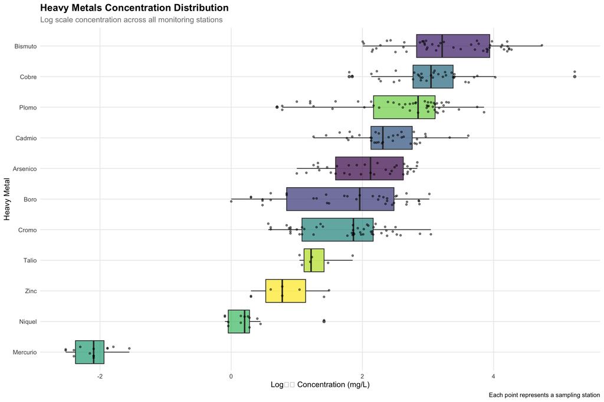

```r
# Create boxplot for heavy metals concentrations
metals_plot <- heavy_metals_data %>%
  mutate(
    log_concentration = log10(concentration_mg_l + 0.001), # Add small value to handle zeros
    parameter = str_remove(parameter, " total")
  ) %>%
  ggplot(aes(x = reorder(parameter, concentration_mg_l, median),
             y = log_concentration)) +
  geom_boxplot(aes(fill = parameter), alpha = 0.7, show.legend = FALSE) +
  geom_jitter(width = 0.2, alpha = 0.5, size = 1) +
  coord_flip() +
  scale_fill_viridis_d() +
  labs(
    title = "Heavy Metals Concentration Distribution",
    subtitle = "Log scale concentration across all monitoring stations",
    x = "Heavy Metal",
    y = "Log₁₀ Concentration (mg/L)",
    caption = "Each point represents a sampling station"
  ) +
  theme_contamination

print(metals_plot)
```

```r
# Calculate contamination index for each station
if(sum(!is.na(station_metadata$latitude)) > 0) {

  station_contamination <- heavy_metals_data %>%
    left_join(who_guidelines, by = "parameter") %>%
    filter(!is.na(who_limit)) %>%
    mutate(
      contamination_ratio = concentration_mg_l / who_limit
    ) %>%
    group_by(station) %>%
    summarise(
      avg_contamination_ratio = mean(contamination_ratio, na.rm = TRUE),
      max_contamination_ratio = max(contamination_ratio, na.rm = TRUE),
      n_metals_above_limit = sum(contamination_ratio > 1, na.rm = TRUE),
      .groups = "drop"
    ) %>%
    left_join(station_metadata, by = "station") %>%
    filter(!is.na(latitude)) %>%
    mutate(
      contamination_category = case_when(
        avg_contamination_ratio <= 1 ~ "Safe",
        avg_contamination_ratio <= 2 ~ "Moderate",
        avg_contamination_ratio <= 5 ~ "High",
        TRUE ~ "Critical"
      )
    )

  # Create contamination map
  pal <- colorFactor(
    palette = c("#2E8B57", "#FFD700", "#FF6347", "#DC143C"),
    domain = c("Safe", "Moderate", "High", "Critical")
  )

  leaflet(station_contamination) %>%
    addTiles() %>%
    addCircleMarkers(
      lng = ~longitude,
      lat = ~latitude,
      radius = ~pmax(5, pmin(20, avg_contamination_ratio * 3)),
      color = ~pal(contamination_category),
      fillOpacity = 0.8,
      popup = ~paste(
        "<b>Station:</b>", station, "<br>",
        "<b>Contamination Level:</b>", contamination_category, "<br>",
        "<b>Avg Ratio vs WHO:</b>", round(avg_contamination_ratio, 2), "<br>",
        "<b>Metals Above Limit:</b>", n_metals_above_limit, "<br>",
        "<b>River:</b>", Río
      )
    ) %>%
    addLegend(
      "bottomright",
      pal = pal,
      values = ~contamination_category,
      title = "Contamination Level"
    )
}
```

[interactive chart not shown]

## Water Quality Parameters Analysis

```r
# Analyze key water quality parameters
wq_summary <- water_quality_data %>%
  group_by(parameter) %>%
  summarise(
    n_samples = n(),
    mean_val = mean(value_numeric, na.rm = TRUE),
    median_val = median(value_numeric, na.rm = TRUE),
    std_dev = sd(value_numeric, na.rm = TRUE),
    min_val = min(value_numeric, na.rm = TRUE),
    max_val = max(value_numeric, na.rm = TRUE),
    .groups = "drop"
  )

# Water quality standards for aquatic life
wq_standards <- tibble(
  parameter = c("pH", "Oxígeno disuelto", "Conductividad específica (T ref. 25°C)"),
  min_safe = c(6.5, 5.0, NA),
  max_safe = c(8.5, NA, 1000),
  units = c("pH units", "mg/L", "µS/cm")
)

wq_assessment <- wq_summary %>%
  left_join(wq_standards, by = "parameter")

DT::datatable(
  wq_assessment %>%
    mutate(across(where(is.numeric), ~ round(.x, 2))),
  caption = "Water Quality Parameters Summary"
)
```

|  | parameter | n_samples | mean_val | median_val | std_dev | min_val | max_val | min_safe | max_safe | units |
| --- | --- | --- | --- | --- | --- | --- | --- | --- | --- | --- |
| 1 | Conductividad específica (T ref. 25°C) | 49 | 2118.5 | 680 | 7742.26 | 234 | 54700 |  | 1000 | µS/cm |
| 2 | Oxígeno disuelto | 49 | 6.31 | 6.34 | 2.2 | 0.81 | 13.62 | 5 |  | mg/L |
| 3 | Sólidos disueltos totales | 48 | 1449.94 | 407.5 | 5703.04 | 114 | 39800 |  |  |  |
| 4 | Sólidos totales | 48 | 5861.82 | 1041.15 | 10550.26 | 230 | 39870.1 |  |  |  |
| 5 | Turbiedad | 27 | 235.42 | 95.2 | 316.58 | 1.51 | 1037.2 |  |  |  |
| 6 | pH | 49 | 7.75 | 7.93 | 1.09 | 3.25 | 9.31 | 6.5 | 8.5 | pH units |

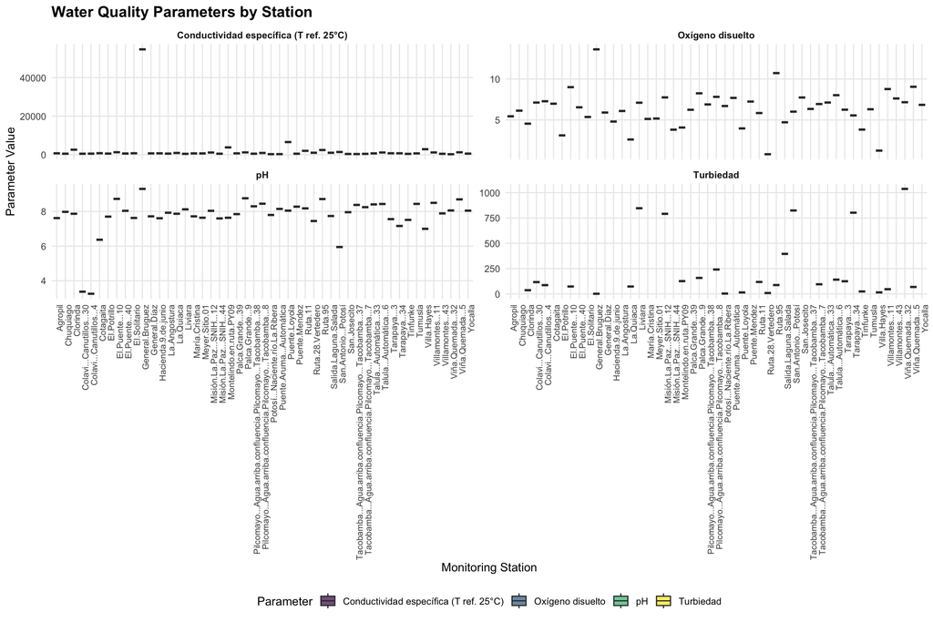

```r
# Create multi-panel plot for key water quality parameters
wq_plots <- water_quality_data %>%
  filter(parameter %in% c("pH", "Oxígeno disuelto", "Conductividad específica (T ref. 25°C)", "Turbiedad")) %>%
  ggplot(aes(x = station, y = value_numeric)) +
  geom_boxplot(aes(fill = parameter), alpha = 0.7) +
  facet_wrap(~parameter, scales = "free_y", ncol = 2) +
  theme_contamination +
  theme(axis.text.x = element_text(angle = 90, hjust = 1, size = 8)) +
  labs(
    title = "Water Quality Parameters by Station",
    x = "Monitoring Station",
    y = "Parameter Value",
    fill = "Parameter"
  ) +
  scale_fill_viridis_d()

print(wq_plots)
```

## Correlation Analysis

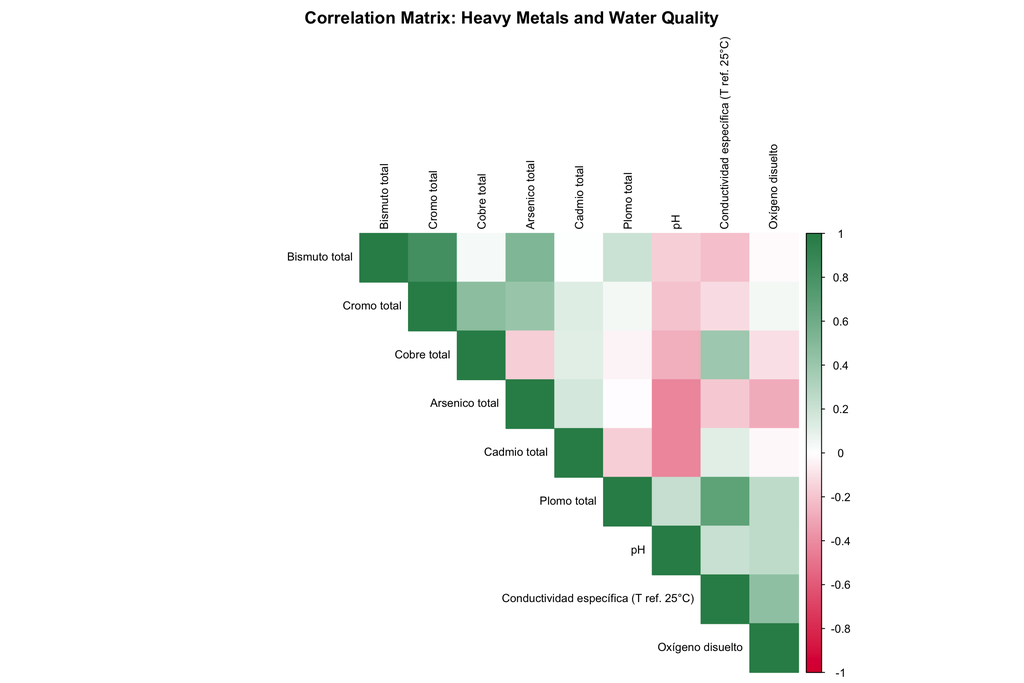

```r
# Create correlation matrix for metals and key parameters
metals_wide <- heavy_metals_data %>%
  select(station, parameter, concentration_mg_l) %>%
  pivot_wider(names_from = parameter, values_from = concentration_mg_l)

# Include key water quality parameters
wq_wide <- water_quality_data %>%
  filter(parameter %in% c("pH", "Conductividad específica (T ref. 25°C)", "Oxígeno disuelto")) %>%
  select(station, parameter, value_numeric) %>%
  pivot_wider(names_from = parameter, values_from = value_numeric)

# Combine datasets
combined_data <- metals_wide %>%
  full_join(wq_wide, by = "station") %>%
  select(-station) %>%
  # Only include variables with sufficient data (at least 5 non-NA values)
  select(where(~ sum(!is.na(.x)) > 5)) %>%
  # Remove columns with zero variance
  select(where(~ var(.x, na.rm = TRUE) > 0))

if(ncol(combined_data) > 1) {
  # Calculate correlation matrix
  cor_matrix <- cor(combined_data, use = "pairwise.complete.obs")

  # Check for any remaining NA/NaN/Inf values and handle them
  if(any(is.na(cor_matrix)) || any(is.infinite(cor_matrix))) {
    # Remove rows/columns with NA correlations
    valid_vars <- !apply(cor_matrix, 1, function(x) any(is.na(x) | is.infinite(x)))
    cor_matrix <- cor_matrix[valid_vars, valid_vars]
  }

  # Only proceed if we have a valid correlation matrix
  if(nrow(cor_matrix) > 1 && all(is.finite(cor_matrix))) {
    # Create correlation plot without hierarchical clustering to avoid issues
    corrplot(
      cor_matrix,
      method = "color",
      type = "upper",
      order = "original",  # Changed from "hclust" to "original"
      tl.cex = 0.8,
      tl.col = "black",
      title = "Correlation Matrix: Heavy Metals and Water Quality",
      mar = c(0, 0, 2, 0),
      col = colorRampPalette(c("#DC143C", "white", "#2E8B57"))(200)
    )
  } else {
    cat("Insufficient valid data for correlation analysis.\n")
  }
} else {
  cat("Insufficient variables for correlation analysis.\n")
}
```

## Priority Contamination Areas

```r
# Identify priority areas for remediation
if(exists("station_contamination")) {
  priority_stations <- station_contamination %>%
    filter(contamination_category %in% c("High", "Critical")) %>%
    arrange(desc(avg_contamination_ratio)) %>%
    select(station, Código, Río, contamination_category,
           avg_contamination_ratio, n_metals_above_limit)

  if(nrow(priority_stations) > 0) {
    DT::datatable(
      priority_stations %>%
        mutate(avg_contamination_ratio = round(avg_contamination_ratio, 2)),
      caption = "Priority Stations for Contamination Remediation",
      options = list(pageLength = 10)
    ) %>%
      formatStyle(
        "contamination_category",
        backgroundColor = styleEqual(
          c("High", "Critical"),
          c("#FF6347", "#DC143C")
        ),
        color = "white",
        fontWeight = "bold"
      )
  } else {
    cat("No stations identified as high priority based on current thresholds.")
  }
}
```

|  | station | Código | Río | contamination_category | avg_contamination_ratio | n_metals_above_limit |
| --- | --- | --- | --- | --- | --- | --- |
| 1 | General.Bruguez | PGB-250 | Pilcomayo | Critical | 238886.67 | 3 |
| 2 | Tarapaya...3 | BTA-050 | Tarapaya | Critical | 199145.12 | 7 |
| 3 | Liviara | ALI-020 | Orosmayo | Critical | 116713 | 5 |
| 4 | Colavi...Canutillos...4 | BC7-113 | Colavi | Critical | 111219.49 | 6 |
| 5 | Clorinda | ACL-310 | Porteño | Critical | 103430 | 2 |
| 6 | Ruta.95 | AR95-220 | Montelindo | Critical | 86580 | 2 |
| 7 | Chuquiago | BCH-060 | San Juan del Oro | Critical | 80817.89 | 6 |
| 8 | Cotagaita | BCO-070 | Cotagaita | Critical | 78242.85 | 7 |
| 9 | San.Antonio...Potosí | BSA-030 | Aljamayu | Critical | 77398.25 | 6 |
| 10 | Puente.Loyola | APL-320 | Pilcomayo | Critical | 74050 | 2 |

[output cut: 39 more lines]

## Mining-Specific Contaminants

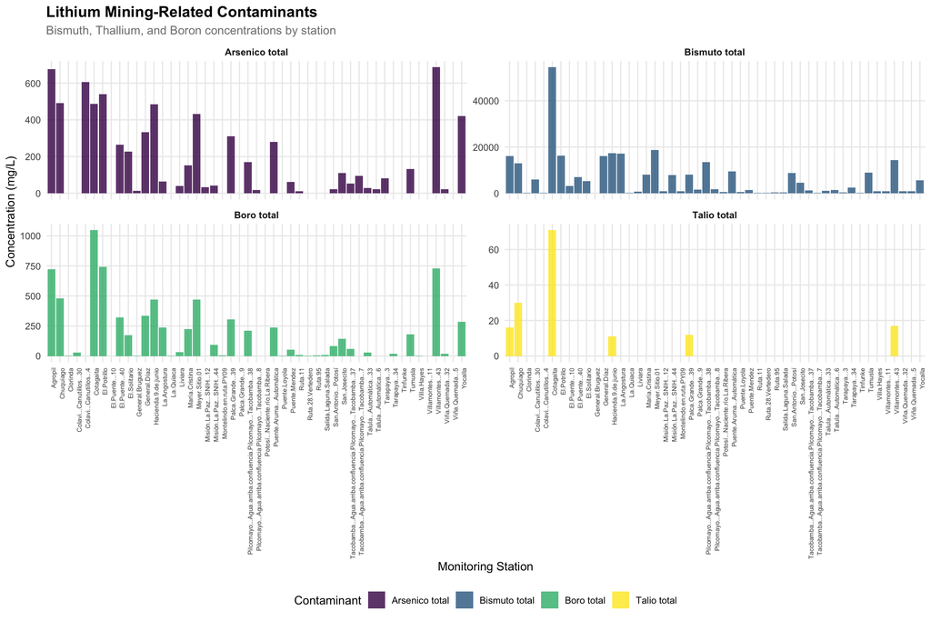

```r
# Focus on lithium mining-related contaminants
mining_metals <- c("Bismuto total", "Talio total", "Boro total", "Arsenico total")

mining_contamination <- heavy_metals_data %>%
  filter(parameter %in% mining_metals) %>%
  group_by(parameter, station) %>%
  summarise(concentration = mean(concentration_mg_l, na.rm = TRUE), .groups = "drop")

if(nrow(mining_contamination) > 0) {
  mining_plot <- mining_contamination %>%
    ggplot(aes(x = station, y = concentration, fill = parameter)) +
    geom_col(position = "dodge", alpha = 0.8) +
    facet_wrap(~parameter, scales = "free_y") +
    theme_contamination +
    theme(axis.text.x = element_text(angle = 90, hjust = 1, size = 6)) +
    labs(
      title = "Lithium Mining-Related Contaminants",
      subtitle = "Bismuth, Thallium, and Boron concentrations by station",
      x = "Monitoring Station",
      y = "Concentration (mg/L)",
      fill = "Contaminant"
    ) +
    scale_fill_viridis_d()

  print(mining_plot)
}
```

## Final Summary

```r
# Generate final assessment
total_stations <- length(unique(heavy_metals_data$station))
contaminated_stations <- if(exists("station_contamination")) {
  sum(station_contamination$contamination_category %in% c("Moderate", "High", "Critical"))
} else { "Data processing required" }

critical_stations <- if(exists("station_contamination")) {
  sum(station_contamination$contamination_category == "Critical")
} else { "Data processing required" }

cat("FINAL ASSESSMENT SUMMARY:\n")
```

```
FINAL ASSESSMENT SUMMARY:
```

```r
cat("========================\n")
cat("Total monitoring stations:", total_stations, "\n")
```

```
Total monitoring stations: 49
```

```r
cat("Stations with contamination concerns:", contaminated_stations, "\n")
```

```
Stations with contamination concerns: 49
```

```r
cat("Critical contamination sites:", critical_stations, "\n")
```

```
Critical contamination sites: 49
```

```r
# Create final summary table
final_results <- tibble(
  Metric = c("Total Monitoring Stations", "Heavy Metals Analyzed", "Water Quality Parameters",
             "Stations with Coordinates", "Sampling Period"),
  Value = c(
    as.character(total_stations),
    as.character(length(heavy_metals)),
    as.character(length(water_quality_params)),
    as.character(sum(!is.na(station_metadata$latitude))),
    "February 2024?"
  )
)

kable(final_results, caption = "Study Overview and Key Metrics")
```

Study Overview and Key Metrics

[output not shown]

## Conclusions

**Next Steps:**

1. Implement immediate source control measures
2. Deploy water treatment systems in priority areas
3. Enhance monitoring network with real-time capabilities
4. Develop long-term remediation strategy
5. Establish baseline for ongoing contamination assessment